# Seaborn Tutorials Oct_23

# Note

Seaborn treats the argument to data as wide form when neither x nor y are assigned.

# *Wide-form data¶*

*For simple datasets, it is often more intuitive to think about data the way it might be viewed in a spreadsheet, where the columns and rows contain levels of different variables. For example, we can convert the flights dataset into a wide-form organization by “pivoting” it so that each column has each month’s time series over years:*

```python
flights_wide = flights.pivot(index = 'year', columns= 'month', values= 'passengers')

flights_wide.head()
```

| month year | Jan | Feb | Mar | Apr | May | Jun | Jul | Aug | Sep | Oct | Nov | Dec |
| --- | --- | --- | --- | --- | --- | --- | --- | --- | --- | --- | --- | --- |
| 1949 | 112 | 118 | 132 | 129 | 121 | 135 | 148 | 148 | 136 | 119 | 104 | 118 |
| 1950 | 115 | 126 | 141 | 135 | 125 | 149 | 170 | 170 | 158 | 133 | 114 | 140 |
| 1951 | 145 | 150 | 178 | 163 | 172 | 178 | 199 | 199 | 184 | 162 | 146 | 166 |
| 1952 | 171 | 180 | 193 | 181 | 183 | 218 | 230 | 242 | 209 | 191 | 172 | 194 |
| 1953 | 196 | 196 | 236 | 235 | 229 | 243 | 264 | 272 | 237 | 211 | 180 | 201 |

```python
flights_wide.shape
```

```
(12, 12)
```

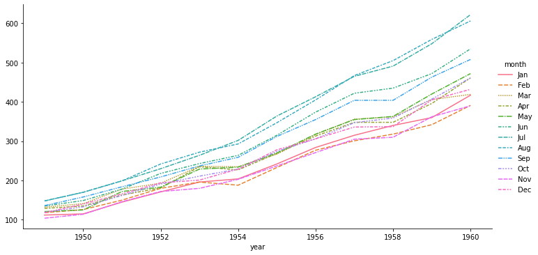

```python
sns.relplot(data = flights_wide, kind = 'line', aspect = 2)
plt.show()
```

```python
flights.head()
```

|  | year | month | passengers |
| --- | --- | --- | --- |
| 0 | 1949 | Jan | 112 |
| 1 | 1949 | Feb | 118 |
| 2 | 1949 | Mar | 132 |
| 3 | 1949 | Apr | 129 |
| 4 | 1949 | May | 121 |

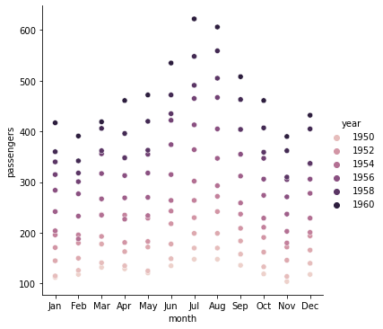

```python
# Long form data

# You can also specify x and y different columns ex:

sns.relplot(data= flights, x= 'month', y= 'passengers', hue= 'year')  # did not specify the "kind"
plt.show()                                                            # It automatically took 'scatter' as kind
```

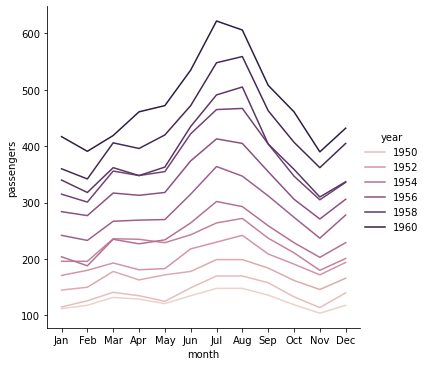

```python
# here I am specifying the kind

sns.relplot(data= flights, x= 'month', y= 'passengers', hue= 'year', kind= 'line')
plt.show()
```

## *Catplot*

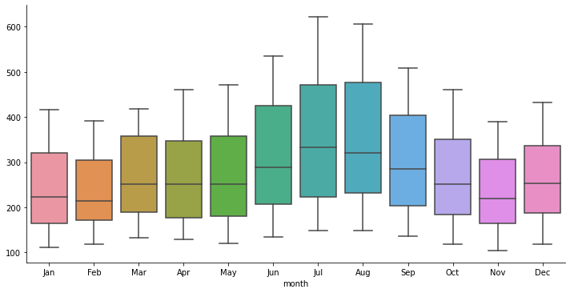

```python
# using categorical variables in flights_wdie

sns.catplot(data= flights_wide, kind = 'box', aspect= 2)  # here it took x as 'month' and y as 'passengers values'
```

# *Histogram in Seaborn*

```python
penguins = sns.load_dataset('penguins')
```

```python
# to save the dataset

# penguins.to_csv("E:\PYTHON\Matplot Seaborn  tutorial pdf\penguins.csv", index = False)
```

```python
df = penguins.copy()
```

```python
df.head()
```

|  | species | island | bill_length_mm | bill_depth_mm | flipper_length_mm | body_mass_g | sex |
| --- | --- | --- | --- | --- | --- | --- | --- |
| 0 | Adelie | Torgersen | 39.1 | 18.7 | 181.0 | 3750.0 | Male |
| 1 | Adelie | Torgersen | 39.5 | 17.4 | 186.0 | 3800.0 | Female |
| 2 | Adelie | Torgersen | 40.3 | 18.0 | 195.0 | 3250.0 | Female |
| 3 | Adelie | Torgersen | NaN | NaN | NaN | NaN | NaN |
| 4 | Adelie | Torgersen | 36.7 | 19.3 | 193.0 | 3450.0 | Female |

```python
df.shape
```

```
(344, 7)
```

## *Lets plot a histogram using the above dataset.*

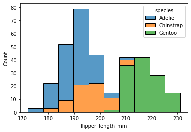

```python
sns.histplot(data = df, x="flipper_length_mm", hue="species", multiple="stack") # here multiple = 'stack'
```

### source information : https://seaborn.pydata.org/tutorial.html

```python
import numpy as np
import pandas as pd
import matplotlib.pyplot as plt
import seaborn as sns
%matplotlib inline
```

```python
# we can use matplot styles
# setting or using plot styles

#plt.style.use('')
```

*numpy.random.multivariate_normal(mean, cov, size=None, check_valid='warn', tol=1e-8)*

```python
# create some data using  random

data = np.random.multivariate_normal([0,0], [[5,2],[2,2]], size = 1000)
```

```python
data
```

```
array([[ 5.69064448,  3.51531741],
       [ 2.45664387,  0.6274418 ],
       [ 3.31676607,  2.22163492],
       ...,
       [-2.27477257, -3.13604297],
       [-1.35404028, -0.30143118],
       [-0.11702812,  1.0808089 ]])
```

```python
df = pd.DataFrame(data = data, columns= ['x', 'y'])

print(df)
```

```
            x         y
0    5.690644  3.515317
1    2.456644  0.627442
2    3.316766  2.221635
3    1.088020  1.811114
4   -0.912525 -1.423160
..        ...       ...
995 -0.404181  1.017482
996 -2.566180  0.386434
997 -2.274773 -3.136043
998 -1.354040 -0.301431
999 -0.117028  1.080809

[1000 rows x 2 columns]
```

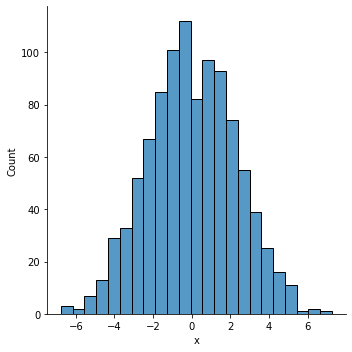

```python
# lets plot using seaborn

sns.displot(data= df, x = 'x')
```

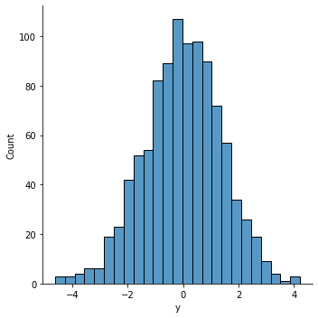

```python
sns.displot(data= df, x = 'y')
```

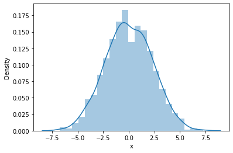

```python
# distplot

sns.distplot(df['x'])
```

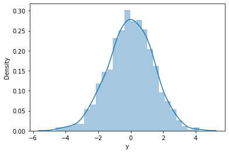

```python
sns.distplot(df['y'])
```

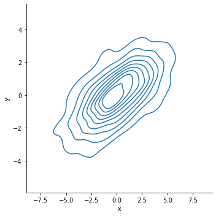

```python
sns.displot(data= df, x= 'x', y= 'y', kind= 'kde');   # ; is used same as plt.show()
```

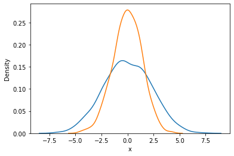

```python
# using for loop plottig 'kdeplot'

for col in 'xy':
    sns.kdeplot(df[col])
```

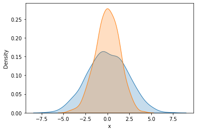

```python
for col in 'xy':
    sns.kdeplot(df[col], shade= 'fill')
```

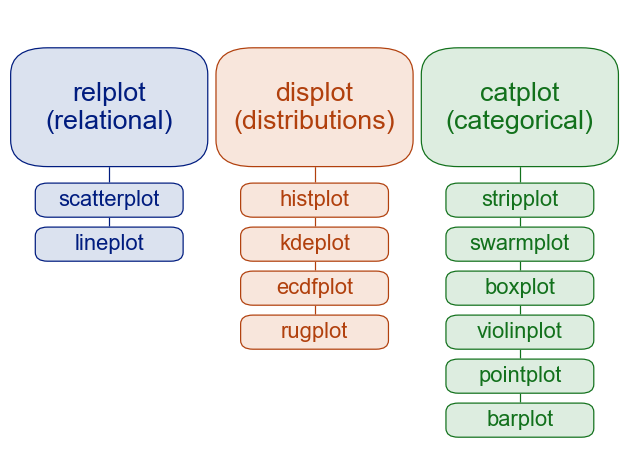

*Different distribution plots*

```
displot : Figure-level interface to distribution plot functions.

histplot : Plot a histogram of binned counts with optional normalization or smoothing.

ecdfplot : Plot empirical cumulative distribution functions.

jointplot : Draw a bivariate plot with univariate marginal distributions.

violinplot : Draw an enhanced boxplot using kernel density estimation.
```

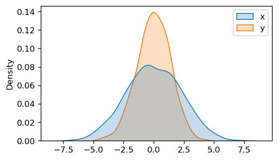

```python
plt.figure(figsize= (5,3), dpi= 120)
sns.kdeplot(data= df, shade= True)
```

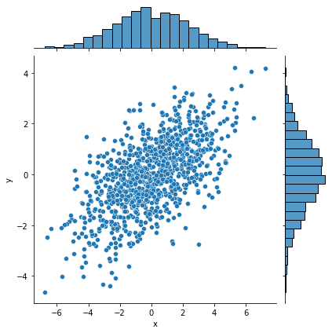

```python
sns.jointplot(data= df, x= 'x', y= 'y');
```

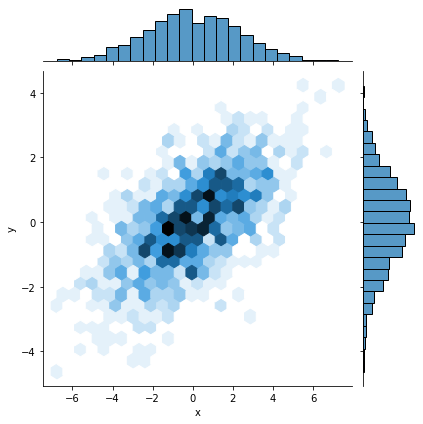

```python
sns.jointplot(data= df, x= 'x', y= 'y', kind= 'hex');
```

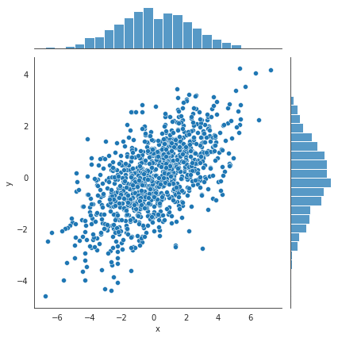

```python
with sns.axes_style('white'):
    sns.jointplot( data= df, x= 'x', y= 'y')
```

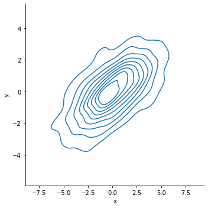

```python
sns.displot(data= df, x= 'x', y= 'y', kind= 'kde')
```

# Oct 27

## Multidimentional relationship

### can be visualize using pairplot

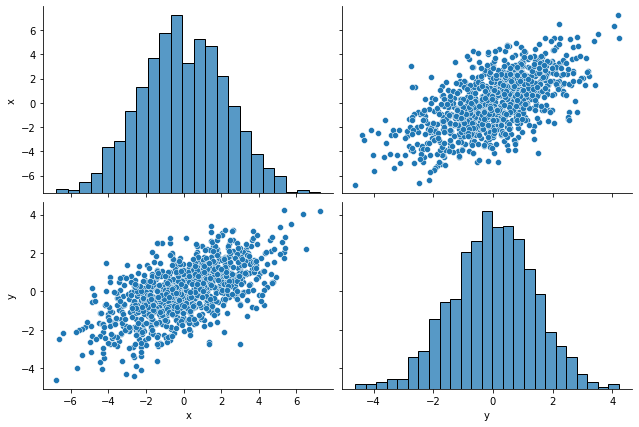

```python
sns.pairplot(data= df, height= 3, aspect=1.5)
```

```python
d1 = np.random.normal(size=(20, 6))

d1
```

```
array([[ 0.7009786 ,  1.36580136,  1.20293978,  0.2181923 , -0.26898987,
        -0.92640007],
       [-0.1010362 , -0.21192029, -0.4412195 , -0.12916638,  1.15979796,
         0.15918399],
       [ 0.77812281, -0.89528452, -0.155595  ,  0.92656476, -1.15101119,
         0.59554063],
       [ 0.54540655,  0.74200943, -1.58880778,  1.69020314, -1.51228508,
        -0.37703394],
       [ 1.21798524,  0.80984581, -0.89601567,  0.64735488,  0.01974391,
         1.83734213],
       [ 1.49489244,  0.64609863,  1.81479268,  0.52343683, -1.44112437,
        -0.09789198],
       [ 1.06894703, -1.46777572,  0.12182167, -0.25580923,  1.59531509,
        -1.42567646],
       [-2.87594508, -0.63540214, -0.57066799,  0.03131782, -0.78938877,
        -0.20743731],
       [ 0.62535111,  0.27517917, -0.25247141,  0.46744149, -0.17298813,
         1.61440664],
       [ 1.00971131, -0.49065694, -0.35659262,  0.31338276,  0.6068472 ,
        -0.69532283],
       [-1.57331195, -0.81592537,  1.88647668,  1.12415787,  1.04394173,
        -0.99642696],
       [-0.44996735,  0.61106134,  0.21589612, -2.47759974, -0.22816017,
        -0.03075988],
       [-0.75803404, -0.91081935, -0.0198262 , -0.01279621,  0.32706674,
        -0.31656683],
       [ 0.01094067,  0.42092725,  0.52396952,  0.47893318,  0.38765345,
         0.33104657],
       [ 0.00926447,  0.34403965, -1.43033601,  0.8252788 , -3.1156813 ,
         0.2097377 ],
       [ 0.70381109, -0.20537171, -0.40918727, -1.31525534, -0.59773701,
        -0.17098842],
       [ 1.95901541,  0.79151318, -1.35989297, -1.35872873,  0.98162421,
         0.40514503],
       [-1.39019929, -0.76329165,  0.25345546,  0.83156972, -0.95453823,
        -0.53563618],
       [-2.22326561, -0.44520632, -0.25633683, -0.56367077, -1.11171187,
        -0.18265699],
       [-0.08813328,  1.47557512,  0.47569064, -0.26205268, -0.76049073,
         1.19748303]])
```

```python
x1 = np.arange(6) / 2

x1
```

```
array([0. , 0.5, 1. , 1.5, 2. , 2.5])
```

```python
# plotting the values

df1 = np.random.normal(size=(20, 6)) + np.arange(6) / 2

print(df1)
```

```
[[ 1.03634012  0.03007987 -0.47509973  1.4472193   3.29862263  2.11426906]
 [ 0.58174147  0.0904169  -0.50090389  2.22466531  3.39604092  1.65743603]
 [-0.43726405  0.92947784  2.4026626   2.07027026  1.98186686  1.64954619]
 [-0.21215307  0.25504202  0.43353709  1.1194989   1.13067184  1.93180622]
 [ 1.34825264 -0.57716369  0.32156179 -0.06844274  4.17207061  2.42641931]
 [ 1.1131437   0.36729896  2.28805732  2.0153582   2.00087254  3.06700394]
 [ 1.62562208  1.75364894  2.03265322  1.58948726  2.45544326  1.76625784]
 [-0.68230006  0.57218854  0.3131286   2.36291337  1.91058526  2.37803822]
 [-2.83540187 -0.43683902  0.8504444   0.07582421  1.34591339  2.54163043]
 [ 0.18920526 -1.18561958  0.12979149 -0.06024554  0.01961348  3.57799022]
 [-0.97198664 -1.11008167  2.0150244   2.23930715  2.20738586  0.63813768]
 [ 0.71378425  2.75240653  1.16937551  1.08842986  0.89132537  1.30234378]
 [-0.77212239  0.15960525  0.76268167  0.79359832  0.99830016  4.13118621]
 [ 2.13058078  0.42398031  1.1312255   1.31040328  1.45248982  4.58831375]
 [-0.47659297  0.03616485  0.65913538  2.51752956  2.21760326  2.77285139]
 [ 0.06700736  1.50096517  1.15216789  1.44363327  4.08263498  1.49186508]
 [-1.06585218  0.77767646  2.19984215  1.09069031  1.23995538  1.98848228]
 [ 0.37298707  0.69034309 -0.23040679 -0.27490539  1.39582884  2.91681779]
 [-0.01834824 -1.61707711 -0.7504323   1.89514753  1.7657911   3.76003112]
 [ 1.2781369   1.06825421  0.42295992  1.55072965  1.82821468  3.20274649]]
```

# *Basic plotting*

```python
jas = pd.DataFrame(np.random.randn(200,6), index = pd.date_range('1/10/2020', periods = 200), columns = list('ABCDEF'))
```

```python
jas
```

|  | A | B | C | D | E | F |
| --- | --- | --- | --- | --- | --- | --- |
| 2020-01-10 | 0.764634 | -0.071197 | -1.084835 | -0.150964 | -1.563224 | 0.132225 |
| 2020-01-11 | 1.034885 | 0.862391 | 0.490194 | 0.120242 | 0.277048 | 1.299664 |
| 2020-01-12 | 1.003972 | -1.585427 | -0.141147 | -0.396227 | 1.549082 | -0.146131 |
| 2020-01-13 | 3.582712 | -1.784577 | 1.992626 | 1.497417 | 0.902288 | 0.530010 |
| 2020-01-14 | -0.536910 | 0.446268 | -1.788324 | -1.885695 | -0.070403 | -0.730442 |
| ... | ... | ... | ... | ... | ... | ... |
| 2020-07-23 | 0.662649 | -0.818664 | 0.744825 | -0.322919 | 1.753925 | 0.820372 |
| 2020-07-24 | 0.076727 | -0.865614 | -0.392348 | 0.452558 | -0.644579 | 1.158950 |
| 2020-07-25 | -0.300602 | 2.095416 | -1.658779 | 1.290554 | 0.748688 | 1.178752 |
| 2020-07-26 | 0.573424 | -0.173952 | 0.261528 | 1.101499 | -0.675547 | -1.563577 |
| 2020-07-27 | 0.577638 | 1.692516 | 0.205583 | -1.456623 | 0.901585 | 0.356291 |

200 rows × 6 columns

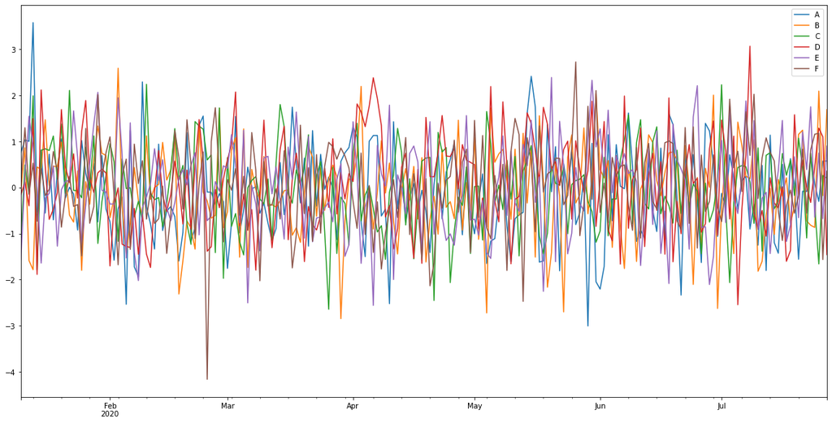

```python
jas.plot(figsize = (20,10))
```

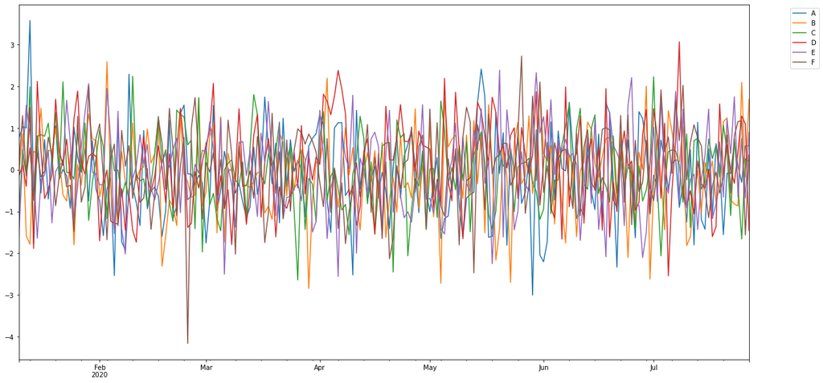

```python
jas.plot(figsize = (20,10)).legend(bbox_to_anchor = (1.1,1))

# legend(bbox_to_anchor = (1.1,1))   is used to get the legend outside the box
```

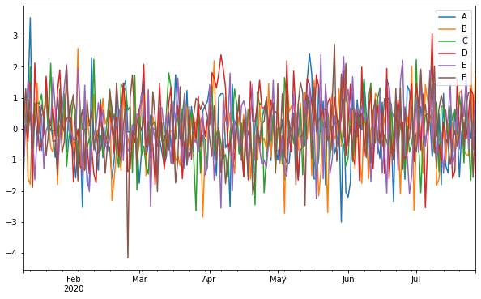

```python
jas.plot(figsize = (10,6))
plt.legend(loc = 1);
```

## another dataframe

```python
rex = pd.DataFrame(np.random.rand(20,5), columns=['Jan','Feb','Mar','April','May'])

rex.head()
```

|  | Jan | Feb | Mar | April | May |
| --- | --- | --- | --- | --- | --- |
| 0 | 0.788400 | 0.250863 | 0.714816 | 0.216248 | 0.883632 |
| 1 | 0.220403 | 0.440349 | 0.979297 | 0.458274 | 0.718567 |
| 2 | 0.958665 | 0.180679 | 0.525387 | 0.318430 | 0.136474 |
| 3 | 0.514997 | 0.860227 | 0.243282 | 0.845949 | 0.172531 |
| 4 | 0.213950 | 0.758100 | 0.201926 | 0.798856 | 0.160411 |

*barplot*

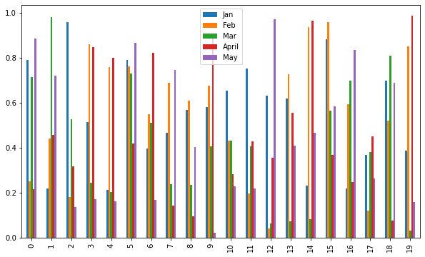

```python
rex.plot.bar(figsize = (10,6))
```

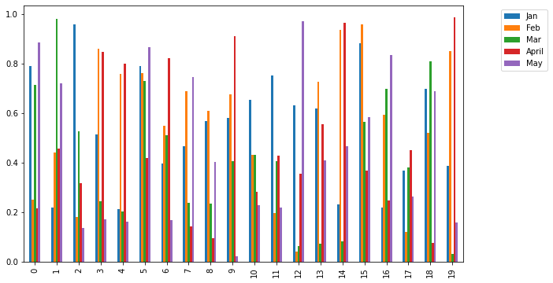

```python
rex.plot.bar(figsize = (10,6)).legend(bbox_to_anchor = (1.2,1))
```

## Stacked bar chart

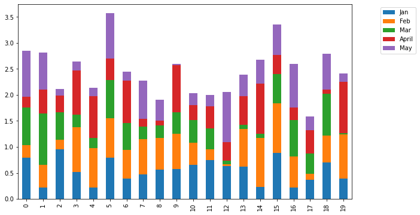

```python
rex.plot.bar(figsize = (10,6), stacked = True)    # stacked = True

plt.legend(bbox_to_anchor = (1.2,1))
```

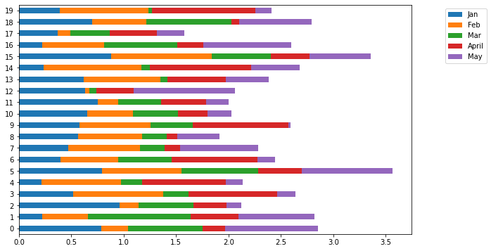

```python
# chainging to horizontal bar plot

rex.plot.barh(figsize = (10,6), stacked = True)    # barh (for horizontal), stacked = True

plt.legend(bbox_to_anchor = (1.2,1))
```

## new dataframe for histogram

```python
his = pd.DataFrame(np.random.rand(10,5), columns= list('ABCDE'))

his.head()
```

|  | A | B | C | D | E |
| --- | --- | --- | --- | --- | --- |
| 0 | 0.243030 | 0.748629 | 0.343892 | 0.452520 | 0.690544 |
| 1 | 0.190207 | 0.122551 | 0.316939 | 0.628889 | 0.221990 |
| 2 | 0.415191 | 0.116911 | 0.213584 | 0.153376 | 0.684843 |
| 3 | 0.660563 | 0.881290 | 0.654270 | 0.409474 | 0.298740 |
| 4 | 0.250639 | 0.540939 | 0.816546 | 0.784699 | 0.801700 |

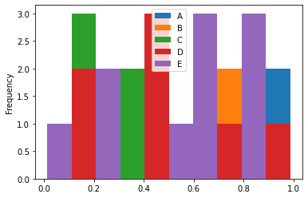

```python
his.plot.hist();
```

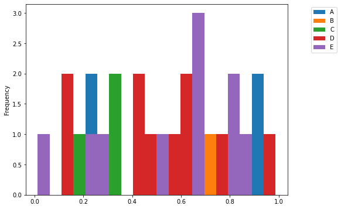

```python
# lets use the bar's bin attribute

his.plot.hist(bins= 20, figsize = (8,6)).legend(bbox_to_anchor = (1.2,1));
```

```python
# Multiple histograms
```